# interval_site_analysis

Jeff Minucci

January 8, 2018

# Introduction

Analysis of 2015 rare data collected by Ohio State - at the site level

To address:

1. Neonics are expressed as sums of the concentrations detected at each sampling date, during the period of interest. It would be more appropriate to take the mean of these concentrations. This should make these values easier to interpret. **Note:** this should not change the results, as each site had the same number of measurements during each period. However, if this were not true, taking sums would lead to erroneous differences between sites.
2. Changes in hive health are expressed in absolute terms, but they may depend on the initial values. For example, a hive that starts with fewer bees may have more potential for growth (or maybe less?). We can try using linear regression models that include the initial values as a covariate.
3. Changes in hive health could also be related to differences in pollen collection (which may in turn be driven by percent corn nearby). We can try using the change in pollen area as a covariate.

# Distribution

The git repo holding this code is available at: https://github.com/puruckertom/rare_pollen

# Computational environment

Version and installed libraries.

```r
verbose_output = TRUE

if(verbose_output){
  print(Sys.info()[4])
  R.Version()$version.string
}
```

```
##          nodename
## "DZ2626UJMINUCCI"
```

```
## [1] "R version 3.4.3 (2017-11-30)"
```

```r
#check to see if needed packages are installed
list.of.packages <- c("ggplot2", "dplyr","corrplot","nlme")
new.packages <- list.of.packages[!(list.of.packages %in% installed.packages()[,"Package"])]
if(length(new.packages)) install.packages(new.packages)
#load relevant packages
library(MASS)
library(dplyr, warn.conflicts = FALSE)
library(ggplot2)
library(reshape2)
library(corrplot)
library(nlme)
if(verbose_output){
  print("list of loaded packages: ")
  print((.packages()))
}
```

```
## [1] "list of loaded packages: "
##  [1] "nlme"      "corrplot"  "reshape2"  "ggplot2"   "dplyr"
##  [6] "MASS"      "stats"     "graphics"  "grDevices" "utils"
## [11] "datasets"  "methods"   "base"
```

# Analytical data

##### Original file with observational data:

https://github.com/puruckertom/rare_pollen/blob/master/data_in/rare_data_osu_2015.csv

```r
##################
#the data sets
##################
#import raw data - everything
#file.exists(paste(osu_data,"CDRC_2017EPA_FP_DBT.csv",sep=""))
osu_covariate <- read.table(paste(osu_data,"CDRC_2017EPA_FP_DBT_clean.csv",sep=""), header = TRUE,
                            sep = ",",strip.white=T,na.strings=c("","NA"))
interval_site <- read.csv(paste(osu_data,"interval_site_level.csv",sep=""),header=T, stringsAsFactors = T)
```

##### Clean and format the data:

```r
## Clean site-level interval data

# Make column names consistent
colnames(interval_site)[1:4] <- c("site_code","interval","n_hives","per_corn")
colnames(interval_site) <- gsub("mean.","",tolower(colnames(interval_site)))
colnames(interval_site) <- ifelse(substr(colnames(interval_site),nchar(colnames(interval_site)),
                                         nchar(colnames(interval_site))) == ".",substr(colnames(interval_site),1,nchar(colnames(interval_site))-1),colnames(interval_site))
colnames(interval_site) <- gsub("\\.","_",colnames(interval_site))

# Remove sums of neonic concentrations
interval_site <- interval_site[,!colnames(interval_site) %in%
                                 c("sumclo_plt","sumclo_all","sumct_plt","sumct_all","sumneo_all")]

# Assign types
interval_site$interval <- factor(interval_site$interval,levels=c(1,2,3))
interval_site$per_corn <- interval_site$per_corn*100


## Create site-level means of the interesting neonics (thiamethoxam and clothianidin) over the planting period and all of May
## For merging with interval_site dataset

mean_may <- aggregate(cbind(FP_thiamethoxam, FP_clothianidin, FP_total_neonic)~site_code,data=osu_covariate,FUN=mean,na.rm=T)
colnames(mean_may)[2:4] <- c("mean_thi_may", "mean_clo_may","mean_total_may")

mean_planting <- aggregate(cbind(FP_thiamethoxam, FP_clothianidin, FP_total_neonic)~site_code,data=subset(osu_covariate,planting=='yes'),FUN=mean,na.rm=T)
colnames(mean_planting)[2:4] <- c("mean_thi_planting", "mean_clo_planting","mean_total_planting")

site_means <- cbind(mean_may,mean_planting[,-1])

#Make site names consistent between datasets
levels(site_means$site_code) <- c(levels(site_means$site_code),"MB","MO")
site_means[site_means$site_code =="MC","site_code"] <- "MB"
site_means[site_means$site_code =="MM","site_code"] <- "MO"
site_means$site_code <- droplevels(site_means$site_code)

## Inner join mean neonic conc. with site-level interval data
interval_site <- merge(interval_site,site_means,by="site_code")


#str(interval_site)

# Write cleaned data to csv
#write.csv(interval_site,paste(osu_data,"interval_site_level_clean.csv",sep=""))

## Convert intervals from long to wide
keep<- colnames(interval_site)[!grepl("chg|interval|n_hives",colnames(interval_site))]
site_wide <- reshape(interval_site,idvar=keep,timevar="interval",direction="wide",sep="_",
                     drop=c("n_hives"),new.row.names=c(1:10))

## Make variables for total change (first observation to final observation)
hive_vars <- c("seam","bee","cap","open","pollen","nectar")
for(i in 1:length(hive_vars)){
  new_var <- rowSums(site_wide[,paste(hive_vars[i],c("1","2","3"),sep="_chg_")])
  site_wide[[paste(hive_vars[i],"_chg_total",sep="")]] <- new_var
}
```

# Create initial value variables (and relative change variables - IN PROGRESS)

Changes in hive health may be more meaningful if they are expressed relative to the initial values.

We may also want to use the initial values as covariates in regression models, if we do use absolute changes.

```r
#Read data, fix column names
frame_data <- read.csv(paste(osu_data,"raw_frame_data.csv",sep=""),stringsAsFactors = T)[1:153,-c(25:34)]
colnames(frame_data) <- gsub("\\.comb","per_comb",colnames(frame_data))
colnames(frame_data) <- tolower(gsub("\\.","",colnames(frame_data)))
colnames(frame_data)[3] <- "per_corn"
frame_data[,grepl("per_comb",colnames(frame_data))] <- as.numeric(gsub("%","",as.matrix(frame_data[,grepl("per_comb",colnames(frame_data))])))
frame_data[["per_corn"]] <- as.numeric(gsub("%","",as.matrix(frame_data[,"per_corn"])))

#Make site DS hive_no consistent ** Note: need to find out what's going on with these DS hives
frame_data$hive_no[frame_data$hive_no == 31.01] <- 31
frame_data$hive_no[frame_data$hive_no == 31.02] <- 32


#convert long to wide format
keep <- colnames(frame_data)[!grepl("cm2|comb|bees|yr_site|date|varroa|month",colnames(frame_data))]
frame_wide <- reshape(frame_data,idvar=keep,timevar="month",direction="wide",sep="_",
                     drop=c("yr_site","date","varroaincomplete"))
colnames(frame_wide)[1] <- "site_code"


##create relative change variables for entire study length (april to august) - for each hive

total_chg <- (frame_wide[,grepl("_8",colnames(frame_wide))] - frame_wide[,grepl("_4",colnames(frame_wide))]) / frame_wide[,grepl("_4",colnames(frame_wide))] * 100

total_chg <- cbind(hive_no = frame_wide$hive_no, site_code = frame_wide$site_code,total_chg)
total_chg <- do.call(data.frame,lapply(total_chg, function(x) replace(x, is.infinite(x),NA)))
colnames(total_chg)[2:ncol(total_chg)] <- gsub("_8","_pchg_total",colnames(total_chg)[2:ncol(total_chg)])


##create initial value variables

initial <- cbind(hive_no = frame_wide$hive_no,site_code = frame_wide$site_code, frame_wide[,grepl("_4",colnames(frame_wide))])
colnames(initial)[2:ncol(initial)] <- gsub("_4","_initial",colnames(initial)[2:ncol(initial)])


#merge with original frame data to create a hive level dataset
new_vars <- merge(total_chg[-2],initial[,-2],by="hive_no")
frame_wide <- merge(frame_wide,new_vars,by="hive_no")

#bring in neonic concentrations from site level data
frame_wide <- merge(site_wide[,grepl("mean_t|mean_clo|site_code",colnames(site_wide))],frame_wide,by="site_code")

#Write new frame level dataset (in wide format)
#write.csv(frame_wide,paste(osu_data,"frame_data_expanded.csv",sep=""))

#Merge initial hive variables into our original site-level dataset
aggregated_initial <- aggregate( . ~ site_code  ,data=frame_wide[,grepl("_initial|site_code",colnames(frame_wide))],
                                 FUN=mean,na.rm=T)
aggregated_initial <- aggregated_initial[,grepl("site_code|seam|bees|capped|open|pollen|nectar",colnames(aggregated_initial)) &
                                           !grepl("per_comb",colnames(aggregated_initial))] #keep only columns in initial (wide) site-level dataset
colnames(aggregated_initial)[2:7] <- c("seam_initial","bee_initial","cap_initial","open_initial","pollen_initial","nectar_initial")
site_wide <- merge(site_wide,aggregated_initial,by="site_code")

#remove variable for ALL neonics and replace with Clo + Thi (to be consistent with manuscript)
site_wide$mean_total_may <- site_wide$mean_clo_may + site_wide$mean_thi_may
site_wide$mean_total_planting <- site_wide$mean_clo_planting + site_wide$mean_thi_planting
colnames(site_wide)[colnames(site_wide) == "mean_total_may"] <- "mean_ct_may"
colnames(site_wide)[colnames(site_wide) == "mean_total_planting"] <- "mean_ct_planting"




## Make dataset analagous to original set but with relative changes instead of absolute
```

# Correlation structure

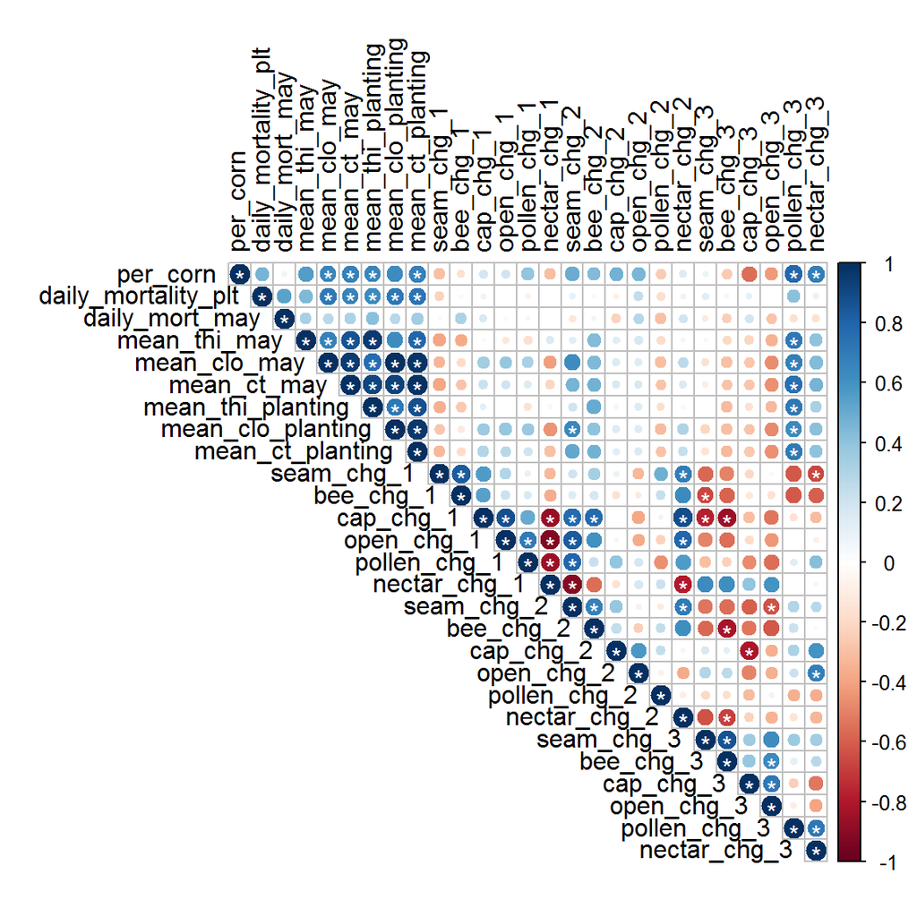

```r
res <- cor.mtest(site_wide[,c(2:28)])
corrplot(cor(site_wide[,c(2:28)]),type="upper",tl.col="black",tl.srt=90,p.mat=res$p,
         insig="label_sig",pch="*",pch.cex=1,pch.col="white")
```

What about for cumulative hive changes our the entire study period?

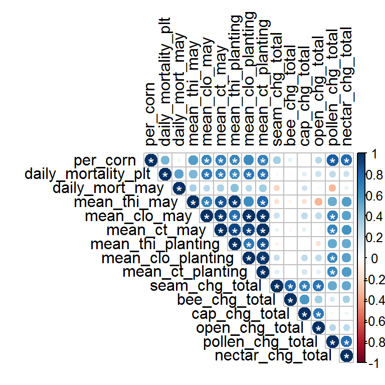

```r
res <- cor.mtest(site_wide[,c(2:10,29:34)])
corrplot(cor(site_wide[,c(2:10,29:34)]),type="upper",tl.col="black",tl.srt=90,p.mat=res$p,
         insig="label_sig",pch="*",pch.cex=1,pch.col="white")
```

# Colony health - PCA

Can we reduce our colony growth variables to fewer dimensions?

- It appears that changes in **area covered by bees** and **seams filled with bees** are postively correlated.
- Changes in area containing **open** and **capped** brood are negatively correlated with changes in area containing **nectar**

```r
colony_pca <- prcomp(interval_site[,7:12],center=T,scale.=T)
summary(colony_pca)
```

```
## Importance of components:
##                           PC1    PC2    PC3     PC4     PC5     PC6
## Standard deviation     1.5409 1.3291 0.9936 0.67428 0.49945 0.40941
## Proportion of Variance 0.3957 0.2944 0.1646 0.07578 0.04158 0.02794
## Cumulative Proportion  0.3957 0.6902 0.8547 0.93049 0.97206 1.00000
```

```r
print(colony_pca)
```

```
## Standard deviations (1, .., p=6):
## [1] 1.5409133 1.3291236 0.9936277 0.6742810 0.4994512 0.4094073
##
## Rotation (n x k) = (6 x 6):
##                   PC1        PC2         PC3         PC4        PC5
## seam_chg    0.4287930 -0.4857858  0.17973155 -0.26546417 -0.1780805
## bee_chg     0.4486932 -0.3950708  0.06927297  0.67691795 -0.1937959
## cap_chg     0.5391936  0.2381240  0.25053768 -0.05916837  0.7633135
## open_chg    0.5067453  0.3223158 -0.11754692 -0.48940875 -0.4882671
## pollen_chg  0.1892983 -0.1206487 -0.94091954  0.02863143  0.2240815
## nectar_chg -0.1773601 -0.6578636  0.03133440 -0.47693740  0.2438560
##                    PC6
## seam_chg    0.66757874
## bee_chg    -0.37685539
## cap_chg    -0.06041316
## open_chg   -0.38415969
## pollen_chg  0.11510086
## nectar_chg -0.49783734
```

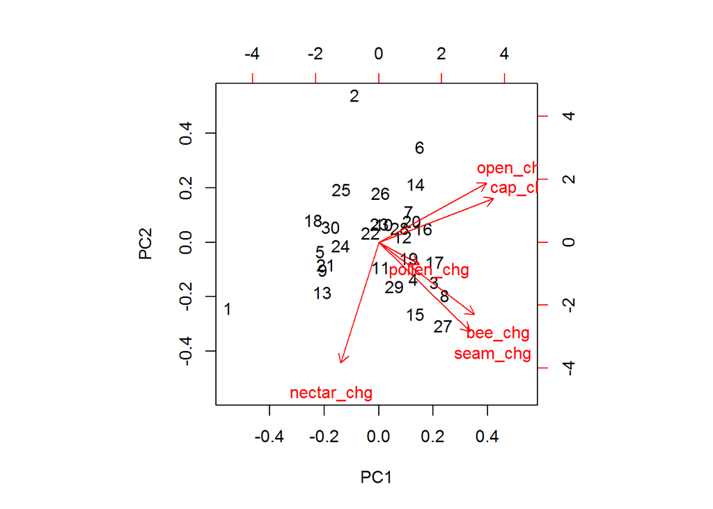

```r
biplot(colony_pca)
```

# Regression analysis

We have already seen that there is greater bee mortality during days when neonic concentrations in pollen are high..

But does greater neonic load in pollen lead to negative hive outcomes, at time of exposure and later?

Let’s also account for the initial characteristics of the hive at the start of the study. We can also try to account for the fact that hives that collect more pollen (perhaps due to corn?) may do better.

```r
fm_1 <- lm(seam_chg_total~mean_ct_planting + seam_initial + pollen_chg_total , data=site_wide)
cat("-------------------------------------\n\n",
    "Does neonic exposure during planting affect bee population change (as measured by # of seams) throughout the season?\n")
```

```
## -------------------------------------
##
##  Does neonic exposure during planting affect bee population change (as measured by # of seams) throughout the season?
```

```r
print(summary(fm_1)) # no effect
```

```
##
## Call:
## lm(formula = seam_chg_total ~ mean_ct_planting + seam_initial +
##     pollen_chg_total, data = site_wide)
##
## Residuals:
##     Min      1Q  Median      3Q     Max
## -3.7526 -2.2690 -0.8631  1.6930  5.6051
##
## Coefficients:
##                    Estimate Std. Error t value Pr(>|t|)
## (Intercept)      12.5080119  4.4739734   2.796   0.0313 *
## mean_ct_planting -0.0811775  0.0966792  -0.840   0.4333
## seam_initial     -0.5203423  0.2001092  -2.600   0.0406 *
## pollen_chg_total  0.0009219  0.0009262   0.995   0.3580
## ---
## Signif. codes:  0 '***' 0.001 '**' 0.01 '*' 0.05 '.' 0.1 ' ' 1
##
## Residual standard error: 3.734 on 6 degrees of freedom
## Multiple R-squared:  0.6802, Adjusted R-squared:  0.5203
## F-statistic: 4.254 on 3 and 6 DF,  p-value: 0.06233
```

```r
#hist(resid(fm_1))

fm_2 <- lm(bee_chg_total~mean_ct_planting+bee_initial+pollen_chg_total,data=site_wide)
cat("-------------------------------------\n\n",
    "Does neonic exposure during planting affect bee population change (as measured by frame area covered by bees) throughout the season?\n")
```

```
## -------------------------------------
##
##  Does neonic exposure during planting affect bee population change (as measured by frame area covered by bees) throughout the season?
```

```r
print(summary(fm_2)) # no effect
```

```
##
## Call:
## lm(formula = bee_chg_total ~ mean_ct_planting + bee_initial +
##     pollen_chg_total, data = site_wide)
##
## Residuals:
##     Min      1Q  Median      3Q     Max
## -3955.0 -1460.1  -875.5  2254.9  4362.3
##
## Coefficients:
##                    Estimate Std. Error t value Pr(>|t|)
## (Intercept)       1.135e+04  4.604e+03   2.466   0.0487 *
## mean_ct_planting -1.156e+01  9.930e+01  -0.116   0.9111
## bee_initial      -2.775e-01  3.456e-01  -0.803   0.4526
## pollen_chg_total  1.364e-02  1.003e+00   0.014   0.9896
## ---
## Signif. codes:  0 '***' 0.001 '**' 0.01 '*' 0.05 '.' 0.1 ' ' 1
##
## Residual standard error: 3624 on 6 degrees of freedom
## Multiple R-squared:  0.1449, Adjusted R-squared:  -0.2827
## F-statistic: 0.3388 on 3 and 6 DF,  p-value: 0.7986
```

```r
#hist(resid(fm_2))


fm_3 <- lm(open_chg_total~mean_ct_planting+open_initial+pollen_chg_total,data=site_wide)
cat("-------------------------------------\n\n",
    "Does neonic exposure during planting affect change in open brood area throughout the season?\n")
```

```
## -------------------------------------
##
##  Does neonic exposure during planting affect change in open brood area throughout the season?
```

```r
print(summary(fm_3)) # no effect
```

```
##
## Call:
## lm(formula = open_chg_total ~ mean_ct_planting + open_initial +
##     pollen_chg_total, data = site_wide)
##
## Residuals:
##      Min       1Q   Median       3Q      Max
## -1208.68  -105.75    76.74   426.40   779.37
##
## Coefficients:
##                    Estimate Std. Error t value Pr(>|t|)
## (Intercept)      3860.76776  983.70596   3.925  0.00776 **
## mean_ct_planting  -20.75507   20.98286  -0.989  0.36079
## open_initial       -1.00636    0.19413  -5.184  0.00205 **
## pollen_chg_total   -0.08121    0.19541  -0.416  0.69217
## ---
## Signif. codes:  0 '***' 0.001 '**' 0.01 '*' 0.05 '.' 0.1 ' ' 1
##
## Residual standard error: 810.8 on 6 degrees of freedom
## Multiple R-squared:  0.8343, Adjusted R-squared:  0.7514
## F-statistic: 10.07 on 3 and 6 DF,  p-value: 0.009313
```

```r
#hist(resid(fm_3))


fm_4 <- lm(cap_chg_total~mean_ct_planting+cap_initial+pollen_chg_total,data=site_wide)
cat("-------------------------------------\n\n",
    "Does neonic exposure during planting affect change in capped brood area throughout the season?\n")
```

```
## -------------------------------------
##
##  Does neonic exposure during planting affect change in capped brood area throughout the season?
```

```r
print(summary(fm_4)) # no effect
```

```
##
## Call:
## lm(formula = cap_chg_total ~ mean_ct_planting + cap_initial +
##     pollen_chg_total, data = site_wide)
##
## Residuals:
##      Min       1Q   Median       3Q      Max
## -2053.32  -725.82   -45.91  1053.84  2329.02
##
## Coefficients:
##                   Estimate Std. Error t value Pr(>|t|)
## (Intercept)      7557.6482  2883.1344   2.621   0.0395 *
## mean_ct_planting   41.6100    44.6939   0.931   0.3878
## cap_initial        -1.1406     0.4531  -2.517   0.0455 *
## pollen_chg_total   -1.0202     0.5241  -1.947   0.0995 .
## ---
## Signif. codes:  0 '***' 0.001 '**' 0.01 '*' 0.05 '.' 0.1 ' ' 1
##
## Residual standard error: 1727 on 6 degrees of freedom
## Multiple R-squared:  0.5341, Adjusted R-squared:  0.3011
## F-statistic: 2.292 on 3 and 6 DF,  p-value: 0.1781
```

```r
#hist(resid(fm_4))

fm_5 <- lm(pollen_chg_total~mean_ct_planting+pollen_initial,data=site_wide)
cat("-------------------------------------\n\n",
    "Does neonic exposure during planting affect change in pollen throughout the season?\n")
```

```
## -------------------------------------
##
##  Does neonic exposure during planting affect change in pollen throughout the season?
```

```r
print(summary(fm_5))# borderline positive effect on pollen change
```

```
##
## Call:
## lm(formula = pollen_chg_total ~ mean_ct_planting + pollen_initial,
##     data = site_wide)
##
## Residuals:
##      Min       1Q   Median       3Q      Max
## -1866.31  -439.81   -64.84   675.64  1245.33
##
## Coefficients:
##                   Estimate Std. Error t value Pr(>|t|)
## (Intercept)      3657.1145   920.1544   3.974  0.00536 **
## mean_ct_planting   46.3418    22.7033   2.041  0.08057 .
## pollen_initial     -0.9029     0.2754  -3.279  0.01350 *
## ---
## Signif. codes:  0 '***' 0.001 '**' 0.01 '*' 0.05 '.' 0.1 ' ' 1
##
## Residual standard error: 1065 on 7 degrees of freedom
## Multiple R-squared:  0.7688, Adjusted R-squared:  0.7027
## F-statistic: 11.64 on 2 and 7 DF,  p-value: 0.005946
```

```r
#hist(resid(fm_5))


fm_6 <- lm(nectar_chg_total~mean_ct_planting+nectar_initial + pollen_chg_total,data=site_wide)
cat("-------------------------------------\n\n",
    "Does neonic exposure during planting affect change in nectar throughout the season?\n")
```

```
## -------------------------------------
##
##  Does neonic exposure during planting affect change in nectar throughout the season?
```

```r
print(summary(fm_6))# no effect
```

```
##
## Call:
## lm(formula = nectar_chg_total ~ mean_ct_planting + nectar_initial +
##     pollen_chg_total, data = site_wide)
##
## Residuals:
##     Min      1Q  Median      3Q     Max
## -8300.3 -1974.6   813.4  3403.0  5428.0
##
## Coefficients:
##                   Estimate Std. Error t value Pr(>|t|)
## (Intercept)      6709.5920  7148.1784   0.939    0.384
## mean_ct_planting   67.0041   161.2450   0.416    0.692
## nectar_initial     -0.2519     1.3353  -0.189    0.857
## pollen_chg_total    2.1783     1.5776   1.381    0.217
##
## Residual standard error: 5332 on 6 degrees of freedom
## Multiple R-squared:  0.592,  Adjusted R-squared:  0.388
## F-statistic: 2.902 on 3 and 6 DF,  p-value: 0.1236
```